# Final Exam Part 1

Malia Mulligan GEOG 495: Final Exam June 14th, 2023

For this portion of the final exam, I will be conducting principal component analysis (PCA) on the climate csv file. Principal component analysis is a statistical technique that allows you to understand which components of a dataset account for the most variance. It is a technique that is often used to understand datasets that have a lot of variables because it allows you to transform or simplify lots of variables into composite components.

By using PCA, I can explore the following questions about the climate dataset:

1. Which components and variables account for most of the data’s variability?
2. Which and how many variables could we omit in the dataset while preserving as much information as possible?

To answer the questions above, we need to understand how much variance different components account for. The greater the variance, the more information the data is explaining.

First, I prepare the R workspace for this analysis. Set the working directory, load in the data and required libraries, and clean up the data to remove any columns which are unnecessary for our analysis. I removed the FIA plot and location columns.

```r
# Set Working Directory to Final Exam Folder
# setwd("/Users/maliamulligan/Documents/GEOG495/Exams")

# Load in the data: 'Final_FIA_plot_climateData.csv'
csvfile <- "Data/Final_FIA_plot_climateData.csv"
climate <- read.csv(csvfile)

# Familarize yourself with the dataset and understand what each column represents
# Structure of the data
str(climate)

# Decide which columns should be included in your analysis and which columns should be omitted.
climate_final <- climate[,-c(1, 7)]

# Load in the libraries you'll need (briefly state what each one is for)
library(psych)
library(ggbiplot)
library(corrplot)
```

Then I make scatter plots of all of the variables to understand the direction and strength of their relationships.

```r
# Write code to make scatter diagrams of all remaining variables in the data set
names(climate_final)

plot(climate_final$mean_annual_temp_degC)
plot(climate_final$elevation_meters)
plot(climate_final$GrowingSeasonLength_months)
plot(climate_final$mean_annual_ppt_cm)
plot(climate_final$Potential_Evapotranspiration_mm_per_month)

# All together in a matrix
plot(climate_final[1:5], main = "Climate Variables Relationship Matrix")
```

From the scatter plot matrix, you can see that there is a strong negative relationship between elevation (meters) and Growing Season Length (Months). This relationship is the most visually linear out of all of the relationships between the different variables.

[figure not shown]

The corrplot is another tool that can be used to udnerstand which variables have the strongest relationships.

```r
# Write code to make correlation diagrams of all the variables in the two data sets
climate_cor <- cor(climate_final[1:5])
corrplot(climate_cor, method = 'color')
```

[output not shown]

```r
climate_matrix <- data.matrix(climate_final)
climate_pca <- prcomp(climate_matrix)

# display the results
climate_pca
summary(climate_pca)
```

From the PCA summary statement, we can see that by transforming the data into principal components, by just including the first component, 95% of the variance is explained. And by looking at the values for each variable for PC1, the elevation (meters) variable accounts for nearly all of PC1, which means it is the most associated with PC1. Then, by including the second component, nearly 100% of the variability is explained. And by looking at the values for each variable for PC2, the mean annual precipitation (cm) variable accounts for almost all of PC2, which means it is th most associated with PC2.

```r
climate_matrix <- data.matrix(climate_final)
climate_pca <- prcomp(climate_matrix)
summary(climate_pca)
```

```
Importance of components:
                            PC1      PC2    PC3     PC4     PC5
Standard deviation     252.9077 52.93700 2.5503 0.88308 0.06431
Proportion of Variance   0.9579  0.04197 0.0001 0.00001 0.00000
Cumulative Proportion    0.9579  0.99989 1.0000 1.00000 1.00000
```

```r
# display the results
climate_pca
```

```
Standard deviations (1, .., p=5):
[1] 252.90774947  52.93700421   2.55032355   0.88308241   0.06431194

Rotation (n x k) = (5 x 5):
                                                    PC1           PC2          PC3          PC4           PC5
mean_annual_temp_degC                     -0.0023146201  0.0104854278  0.075414302 -0.996955116 -0.0166696524
mean_annual_ppt_cm                         0.0897338694  0.9958857545  0.006581315  0.010769177 -0.0003282702
elevation_meters                           0.9959479026 -0.0897417357  0.005074042 -0.002879031  0.0004018107
Potential_Evapotranspiration_mm_per_month -0.0054858318 -0.0069088218  0.997116783  0.075323377  0.0025852744
GrowingSeasonLength_months                -0.0003951834  0.0005557076 -0.001320757 -0.016811329  0.9998575748
```

```r
summary(climate_pca)
```

```
Importance of components:
                            PC1      PC2    PC3     PC4     PC5
Standard deviation     252.9077 52.93700 2.5503 0.88308 0.06431
Proportion of Variance   0.9579  0.04197 0.0001 0.00001 0.00000
Cumulative Proportion    0.9579  0.99989 1.0000 1.00000 1.00000
```

The scree plot is a helpful visualization tool for deciding how many principal components we need to include. Where the line levels off in the plot, we can choose to include the principal components, but it does not add much to the analysis. In the case of this data, the line begins to level off around the 3rd or 4th principal component.

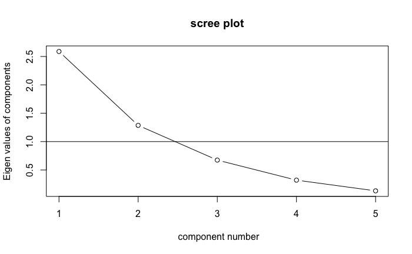

```r
VSS.scree(climate_matrix)
```

All of this information matches our current understanding of the variables which we also gleaned from the summary statement of the PCA.

At the beginning of this exercise, I mentioned that there were two main questions I wanted to answer: 1). Which components and variables account for most of the data’s variability? 2). Which and how many variables could we omit in the data set while preserving as much information as possible?

From our analysis, we know that just the first two components account for ane explain nearly all of the variance in the dataset. Furthermore, we know that elevation (m) explains nearly all of PC1 and the average annual precipitation (cm) explains nearly all of PC2. Therefore, these variables are the most important predictors of this data, and omitting the rest of the principal components and variables would not remove much information in the dataset.